# Master_Юлия Шаталина_review (1)

Построим матрицу ошибок и кривую ROC-AUC

```python
pred= gscv_lr.best_estimator_.predict(features_test)
```

```python
confusion_matrix = metrics.confusion_matrix(target_test, pred)
```

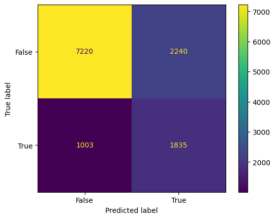

```python
cm_display = metrics.ConfusionMatrixDisplay(confusion_matrix = confusion_matrix, display_labels = [False, True])

cm_display.plot()
plt.show()
```

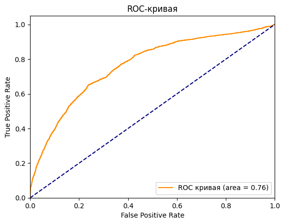

```
ROC_AUC Метрика:  0.76
```

```python
fpr, tpr, treshold = roc_curve(target_test, gscv_lr.best_estimator_.predict_proba(features_test)[:, 1])
roc_auc = auc(fpr, tpr)
# строим график
plt.plot(fpr, tpr, color='darkorange',
         label='ROC кривая (area = %0.2f)' % roc_auc)
plt.plot([0, 1], [0, 1], color='navy', linestyle='--')
plt.xlim([0.0, 1.0])
plt.ylim([0.0, 1.05])
plt.xlabel('False Positive Rate')
plt.ylabel('True Positive Rate')
plt.title('ROC-кривая')
plt.legend(loc="lower right")
plt.show()
print('ROC_AUC Метрика: ',round(roc_auc_score(target_test, gscv_lr.best_estimator_.predict_proba(features_test)[:, 1]),2))
```

Выделим самые важные фичи, повлиявшие на результат предсказания.

Найдем коэффициенты уравнения, описывающего предсказание. Создадим датафрейм, куда впишем наименования фич и коэффициенты, пронажируем их, построим график.

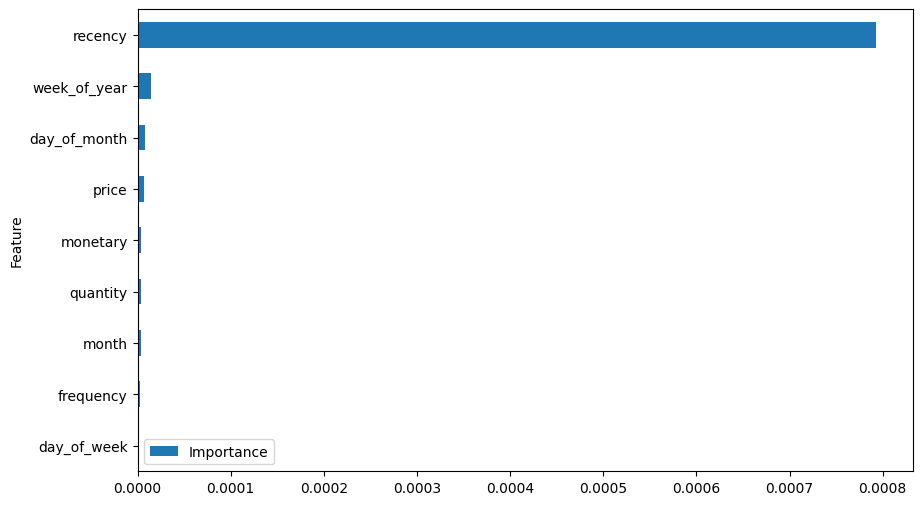

```python
coefficients = gscv_lr.best_estimator_.coef_[0]

avg_importance = np.abs(coefficients)
feature_importance = pd.DataFrame({'Feature': features_train.columns, 'Importance': avg_importance})
feature_importance = feature_importance.sort_values('Importance', ascending= True)
feature_importance.plot(x='Feature', y='Importance', kind='barh', figsize=(10, 6))
```

## Вывод по исследованию данных и построению модели

### Общий вывод по данным

По таблице apparel_purchases:

- Дана таблица на 133104 строк без пропусков
- Есть 59279 строк дубликатов, часть из них не 100%
- Данные даны за год с 26.10.2022 по 26.10.2023 года
- Удалили столбцы message_id, recommended_by
- Дубликаты не стали удалять
- В основном товары куплены в количестве 1 штука
- Стоимость покупки составляет в среднем 1110 рублей
- Большая часть покупок стоит 1500 рублей
- Можно отметить пик покупок в ноябре - вероятно связано с распродажами 11.11, пики перед празниками и летом - в сезон смены одежды

По таблице market_purchases:

- Дана таблица на 48182 строки без пропусков
- Есть 9026 строк дубликатов, часть из них не 100%
- Привели формат даты к значению год-месяц-день
- Данные даны за год с 26.10.2022 по 26.10.2023 года
- Удалили столбцы message_id, created_at
- Дубликаты не стали удалять
- В основном товары куплены в количестве 1 штука
- Стоимость покупки составляет в среднем 27919 рублей
- Есть пики продаж осенью, весной

По таблице gifts_purchases:

- Дана таблица на 810 строк без пропусков
- Есть 56 строк дубликатов, часть из них не 100%
- Данные представлены за год с 26.10.22 по 24.10.23
- Удалили столбцы message_id, recommended_by
- Дубликаты не стали удалять
- Почти все товары куплены в количестве 1 штука
- Средняя цена покупки 14,5 тысяч рублей
- Большинство покупок сосредоточено в ценовом диапазоне до 25 тысяч рублей
- Есть тренд к покупкам перед праздниками

Вывод подготовки данных:

- Собрали все данные по таблицам в единую
- Построили график зависимости ухода клиентов от даты. По данным apparel и market - клиенты часто уходят после первой покупки, в gifts они плавно уходят в течение пары месяцев.
- Добавили метку по магазинам
- Добавили признаки Общая сумма покупок, Общее число покупок, Средняя цена покупки, Общий период покупок, Период с последней покупки
- Выделили таргет как ID клиентов, которые купили в последние 30 дней данных - 1 и 0, если покупки не было
- Обучение моделей проходит на данных до Последняя дата данных - 30 дней
- Признаки разделены на категориальные и цифровые
- Провели шкалирование и кодирование данных
- Есть сильный дисбаланс - число положительных ответов составляет примерно 1,5 %

## Вывод по обучению моделей:

- Провели обучение моделей - 'KNeighbors', 'GradientBoosting', 'RandomForest', 'SVC', 'LogisticRegression', 'CatBoost' и 'Dummy' - последняя чтобы убедиться, что лучшая модель работает не хуже примитивной
- Построили графики метрик 'recall_score', 'precision_score', 'f1', 'roc_auc' для всех моделей
- Лучший показатель у модели SVC с параметрами {'C': 0.1, 'class_weight': 'balanced', 'kernel': 'linear'}
- Показатели метрик лучшей модели:
- - 'recall_score' - 0.76
- - 'precision_score' - 0.04
- - 'f1' - 0.07
- - 'roc_auc' - 0.73
- Делаем выводы, что модель предсказывает хорошо доминирующий класс, но не искомый
- Попробуем улучшить результаты за счет добавления новых временных признаков и расчета модели на временном ряде

Выводы добавления новых признаков: